# Introduction to Biostatistics

# 1 Learning objectives

## 1.1 Learning objectives

- **Conduct** logistic regression for *binary outcomes*
- **Interpret** results in terms of *probability*, *odds*, and *log-odds*

# 2 Linear regression review

## 2.1 Assumptions of linear regression

General linear model (GLM, linear regression, ANOVA) makes **three assumptions** about the **residuals** ($e_i = Y_i - \hat{Y}_i$) of the model

1. **Independence**: observations (i.e., residuals) from different subjects **do not depend on one another**
2. **Constant variance** (homoscedasticity): **variance of residuals is same** at all values of predictor(s)
3. **Conditional normality**: **residuals are normally distributed** at each value of predictor(s)

## 2.2 ICU data

```r
library(Stat2Data)
data(ICU)
head(ICU)
```

```
  ID Survive Age AgeGroup Sex Infection SysBP Pulse Emergency
1  4       0  87        3   1         1    80    96         1
2  8       1  27        1   1         1   142    88         1
3 12       1  59        2   0         0   112    80         1
4 14       1  77        3   0         0   100    70         0
5 27       0  76        3   1         1   128    90         1
6 28       1  54        2   0         1   142   103         1
```

## 2.3 Linear regression on normal outcome

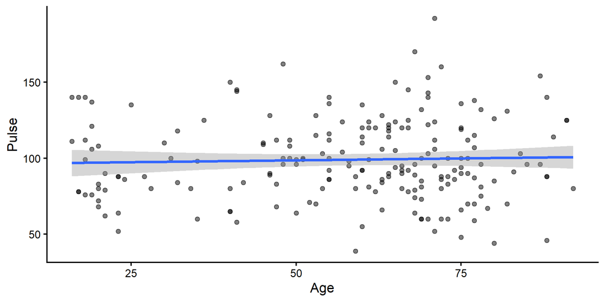

```r
ggplot(data = ICU,
       aes(x = Age,
           y = Pulse)) +
  geom_point(alpha = 0.5) +
  geom_smooth(method = "lm")
```

## 2.4 Assumptions met!

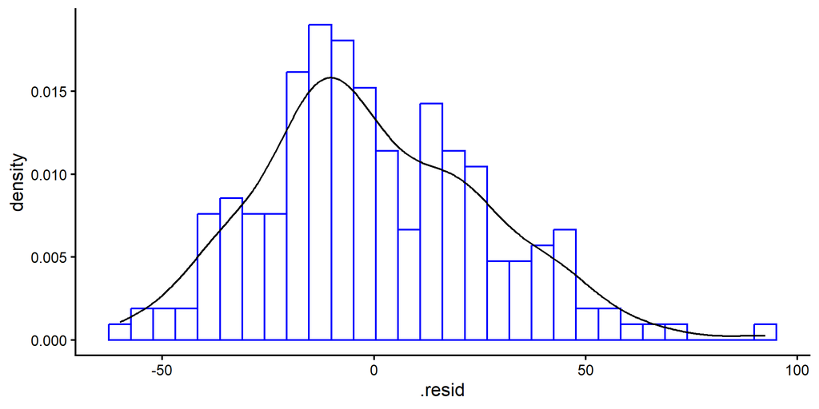

```r
m1_norm <- lm(Pulse ~ Age,
              data = ICU)
m1_norm_resid <- augment(m1_norm)
ggplot(data = m1_norm_resid,
       aes(x = .resid)) +
  geom_histogram(aes(y = ..density..),
                 fill = "white",
                 color = "blue") +
  geom_density()
```

## 2.5 Assumptions met!

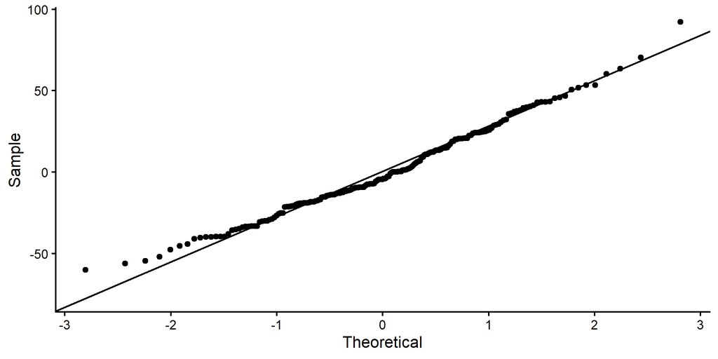

```r
ggplot(data = m1_norm_resid,
       aes(sample = .resid)) +
  geom_qq() +
  geom_qq_line() +
  labs(x = "Theoretical",
       y = "Sample")
```

## 2.6 Assumptions met!

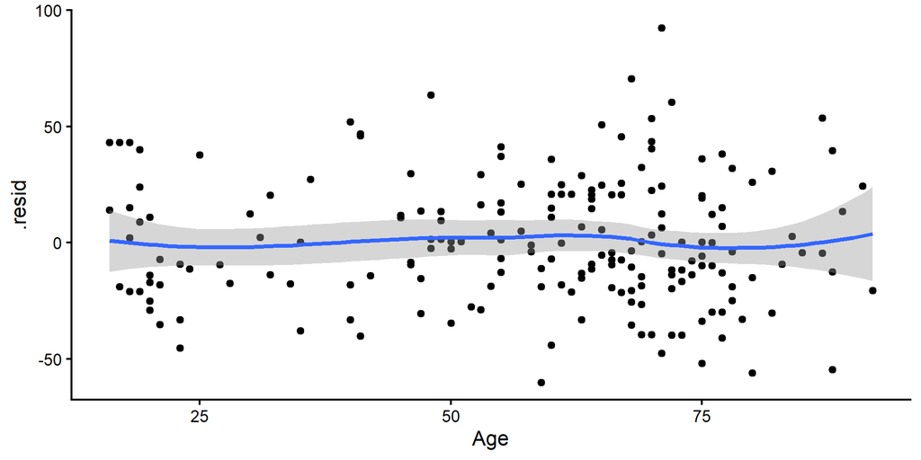

```r
ggplot(data = m1_norm_resid,
       aes(x = Age,
           y = .resid)) +
  geom_point() +
  geom_smooth()
```

# 3 Binary variable

## 3.1 A binary variable is not normal

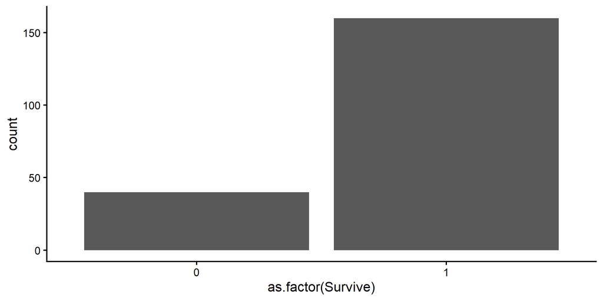

```r
ggplot(data = ICU,
       aes(x = as.factor(Survive))) +
  geom_bar()
```

## 3.2 Plot of data with fit line

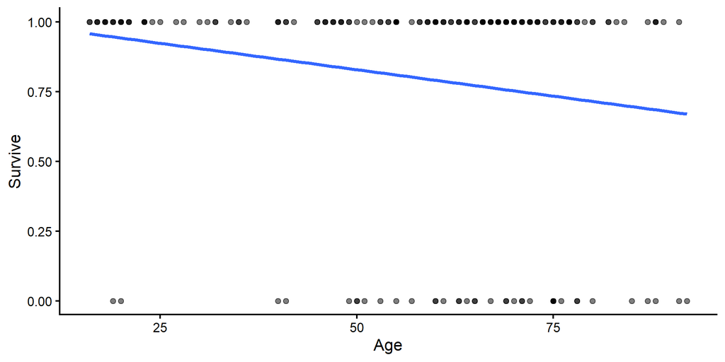

```r
ggplot(data = ICU,
       aes(x = Age,
           y = Survive)) +
  geom_point(alpha = 0.5) +
  geom_smooth(method = "lm",
              se = FALSE) +
  coord_cartesian(ylim = c(0,1))
```

## 3.3 Plot of data with fit line

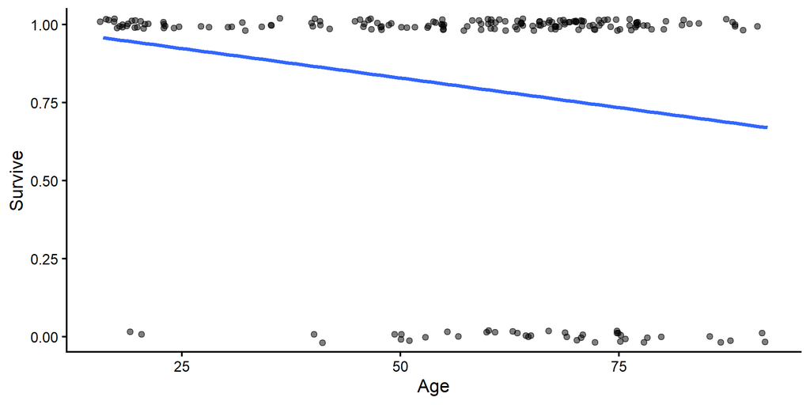

```r
ggplot(data = ICU,
       aes(x = Age,
           y = Survive)) +
  geom_jitter(height = 0.02,
              alpha = 0.5) +
  geom_smooth(method = "lm",
              se = FALSE) +
  coord_cartesian(ylim = c(0,1))
```

## 3.4 Plot of residuals

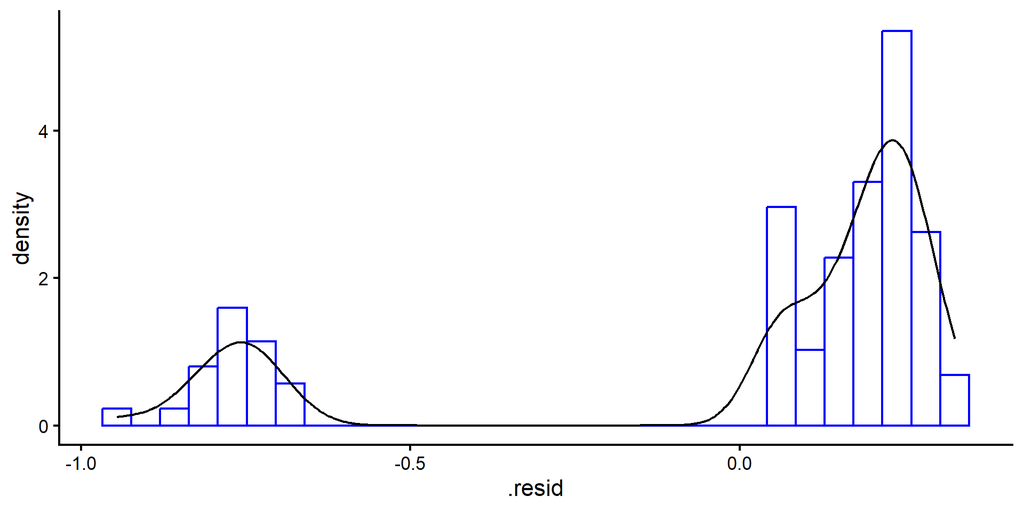

```r
m1_bin <- lm(Survive ~ Age,
             data = ICU)
resids_m1_bin <- augment(m1_bin)
ggplot(data = resids_m1_bin,
       aes(x = .resid)) +
  geom_histogram(aes(y = ..density..),
                 fill = "white",
                 color = "blue") +
  geom_density()
```

## 3.5 Plot of residuals

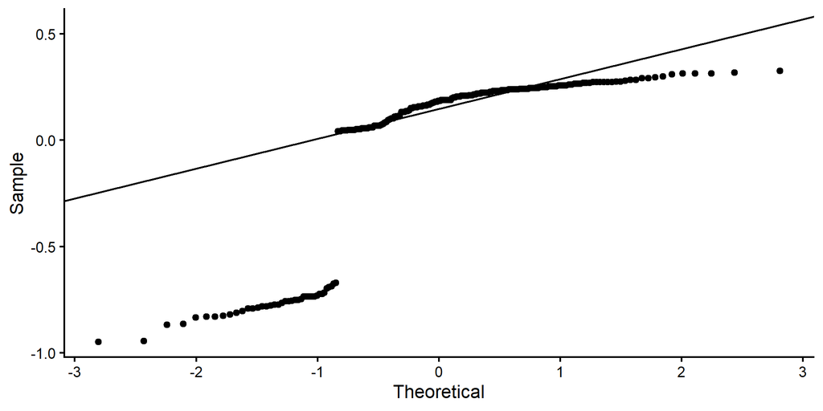

```r
ggplot(data = resids_m1_bin,
       aes(sample = .resid)) +
  geom_qq() +
  geom_qq_line() +
  labs(x = "Theoretical",
       y = "Sample")
```

## 3.6 Plot of residuals

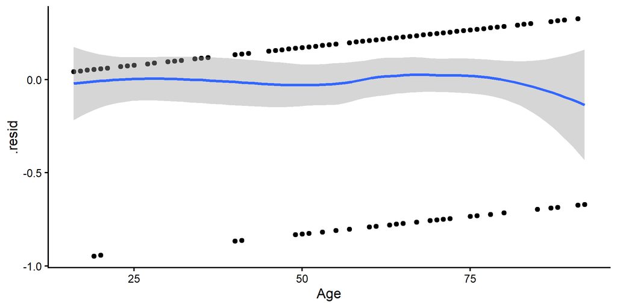

```r
ggplot(data = resids_m1_bin,
       aes(x = Age,
           y = .resid)) +
  geom_point() +
  geom_smooth()
```

## 3.7 What **NOT** to do

- **Ignore** the problem
  - Do linear regression anyway
  - Call it **linear probability model**
- **Transform** the *outcome*
  - Square root, natural log, etc.
  - May *slightly* normalize *univariate* residual distribution
  - **Does not fix heteroscedasticity, (conditional) non-normality**

## 3.8 A binary variable is not normal

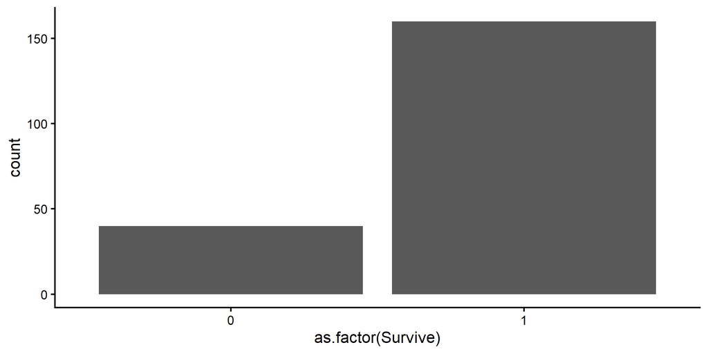

## 3.9 What to do

- **Generalized linear model (GLiM)**
  - Not a single model but a **family** of regression models
  - **Choose** features (e.g., residual distribution) to match the **characteristics** of your outcome variable
  - Accommodates many **continuous** and **categorical** outcome variables
  - Includes **logistic regression** and **Poisson regression**
  - Transformation of the **predicted** outcome

# 4 Logistic regression

## 4.1 (Binary) logistic regression

- **Outcome**: binary
  - Observed value ($Y$): 0 or 1, where 1 = “success” or “event”
  - Predicted value ($\hat{Y}$): **Probability** of success, between 0 and 1
- **Residual/outcome distribution**: binomial
- **Link function**: logit (or log-odds) = $ln\Big(\frac{\hat{Y}}{1 - \hat{Y}}\Big) = ln\left(\frac{\hat{p}}{1-\hat{p}}\right)$

$$ln\left(\frac{\hat{p}}{1-\hat{p}}\right) = b_0 + b_1 X_1 + b_2 X_2 + \cdots + b_p X_p$$

## 4.2 Reminder: normal distribution

$$f(x) = {\frac {1}{{\sqrt {2\pi \sigma^2}}}}e^{-{\frac {(x-\mu)^2 }{2 \sigma^2 }}}$$

Mean of normal distribution = $\mu$

Variance of normal distribution = $\sigma^2$

- Mean and variance are **different parameters** and are **unrelated**
- **Homoscedasticity**: Constant variance doesn’t depend on mean

## 4.3 Binomial distribution

Probability of $k$ events in $n$ trials, each with probability $p$ of event?

- $p$ = 0.5, $n$ = 10

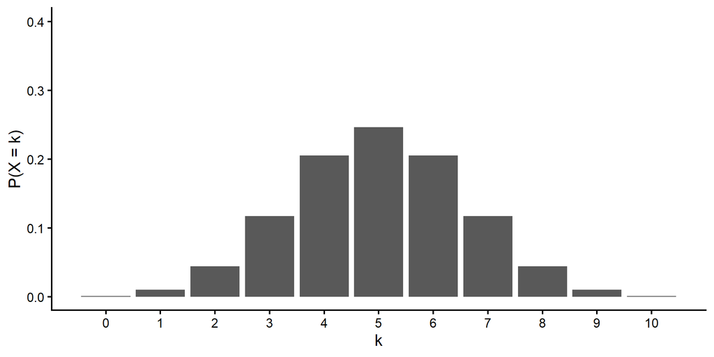

```r
n <- 10
p <- 0.5
k <- seq(0, 10, 1)
Prob <- dbinom(k, n, p)
bin0_5 <- data.frame(k, Prob)
ggplot(data = bin0_5, aes(x = k, y = Prob)) +
  geom_col() +
  scale_x_continuous(breaks=seq(0,10,1)) +
  scale_y_continuous(breaks = c(0, 0.1, 0.2, 0.3, 0.4, 0.5)) +
  ylim(0,0.4) +
  labs(y = "P(X = k)")
```

- $p$ = 0.1, $n$ = 10

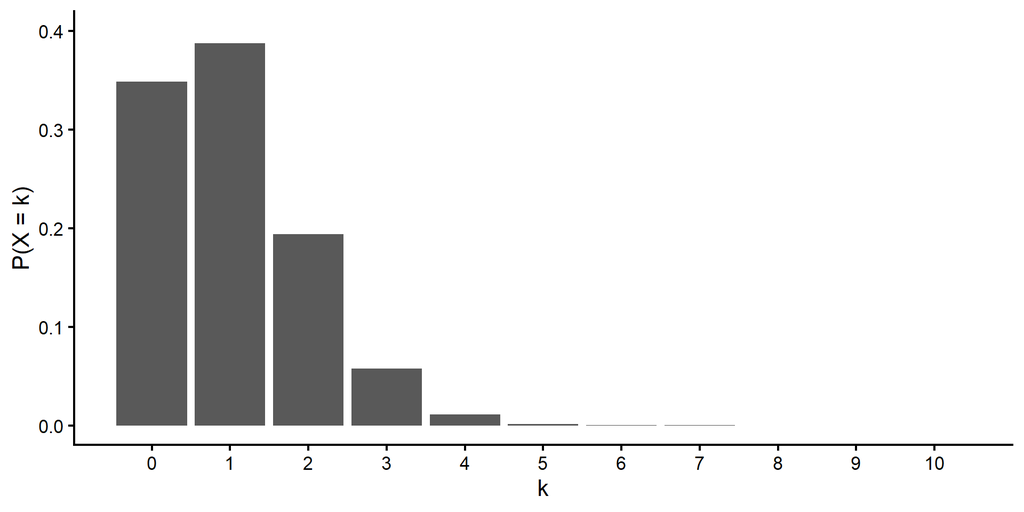

```r
n <- 10
p <- 0.1
k <- seq(0, 10, 1)
Prob <- dbinom(k, n, p)
bin0_2 <- data.frame(k, Prob)
ggplot(data = bin0_2, aes(x = k, y = Prob)) +
  geom_col() +
  scale_x_continuous(breaks=seq(0,10,1)) +
  scale_y_continuous(breaks = c(0, 0.1, 0.2, 0.3, 0.4, 0.5)) +
  ylim(0,0.4) +
  labs(y = "P(X = k)")
```

## 4.4 Binomial distribution

$$P(X = k) = {n \choose k} p^k (1-p)^{n-k}$$

Mean of a binomial distribution: $np$  
Variance of a binomial distribution: $np(1-p)$

- Mean and variance are **related** to one another
  - They are functions of the same parameters ($n$ and $p$)
- **Heteroscedasticity is built into logistic regression**

## 4.5 Logistic regression: What we model

- Linear regression: Model the **mean** of the outcome
  - Observed and predicted outcome are the *same type of variable*
- Logistic regression: Model the **probability of a “success” or “event”**
  - Observed is **binary** (**0 or 1**)
  - Predicted is **probability** (**from 0 to 1**)
  - From the **probability**, we can also get the **odds** of a success and the **logit or log-odds** of a success

## 4.6 Logistic regression model

- `glm()` function in **stats** package (always loaded)
  - `data`: same as `lm()`
  - `formula`: same as `lm()`
  - `family`: Residual distribution and link function

```r
ICU <- ICU %>% mutate(AgeC = Age - mean(Age, na.rm = TRUE))
m1 <- glm(data = ICU,
          Survive ~ AgeC,
          family = binomial(link = "logit"))
```

```r
m1_b0 <- round(coefficients(m1)[1], 3)
m1_b1 <- round(coefficients(m1)[2], 3)
```

## 4.7 Logistic regression model

- Estimate
- Standard error
- **$z$ statistic**
- $p$-value
- **No $R^2$**
- Deviance value

```r
summary(m1)
```

```
Call:
glm(formula = Survive ~ AgeC, family = binomial(link = "logit"),
    data = ICU)

Coefficients:
            Estimate Std. Error z value Pr(>|z|)
(Intercept)  1.47357    0.19133   7.702 1.34e-14 ***
AgeC        -0.02754    0.01056  -2.607  0.00913 **
---
Signif. codes:  0 '***' 0.001 '**' 0.01 '*' 0.05 '.' 0.1 ' ' 1

(Dispersion parameter for binomial family taken to be 1)

    Null deviance: 200.16  on 199  degrees of freedom
Residual deviance: 192.31  on 198  degrees of freedom
AIC: 196.31

Number of Fisher Scoring iterations: 4
```

## 4.8 Figure: What we model

```r
ggplot(ICU,
       aes(x=AgeC,
           y=Survive)) +
  geom_point() +
  stat_smooth(method="glm",
              method.args=list(family="binomial"),
              se=FALSE)
```

[output not shown]

## 4.9 Three forms of logistic regression

Probability:

$$\hat{p} = \frac{e^{(\color{OrangeRed}{b_0 + b_1 X_1 + b_2 X_2 + \cdots + b_p X_p})}}{1+e^{(\color{OrangeRed}{b_0 + b_1 X_1 + b_2 X_2 + \cdots + b_p X_p})}}$$

Odds:

$$\hat{odds} = \frac{\hat{p}}{1-\hat{p}} = e^{\color{OrangeRed}{b_0 + b_1 X_1 + b_2 X_2 + \cdots + b_p X_p}}$$

Logit:

$$ln\left(\frac{\hat{p}}{1-\hat{p}}\right) = \color{OrangeRed}{b_0 + b_1 X_1 + b_2 X_2 + \cdots + b_p X_p}$$

# 5 Probability metric

## 5.1 What is probability ($p$)?

- Likelihood of a “success” or “event”
- Ranges from 0 to 1 (inclusive)
- Both options are equally likely when $p = 0.5$

## 5.2 $\hat{p} = \frac{e^{1.474 + -0.028 X}}{1 + e^{1.474 + -0.028 X}}$

```r
ggplot(ICU,
       aes(x=AgeC,
           y=Survive)) +
  geom_point() +
  stat_smooth(method="glm",
              method.args=list(family="binomial"),
              se=FALSE)
```

[output not shown]

## 5.3 $\hat{p} = \frac{e^{1.474 + -0.028 X}}{1 + e^{1.474 + -0.028 X}}$

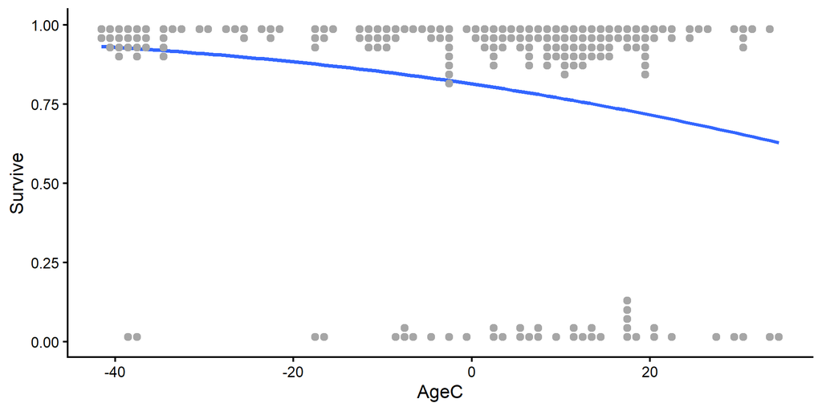

```r
library(ggdist)
ggplot(ICU,
       aes(x=AgeC,
           y=Survive)) +
  #geom_point() +
  stat_smooth(method="glm",
              method.args=list(family="binomial"),
              se=FALSE) +
  stat_dots(data = ICU,
            aes(y = Survive,
                side = ifelse(Survive == 0,
                              "top",
                              "bottom")),
            scale = 1/5)
```

## 5.4 Interpreting probability

- **Intercept**: $b_0$ is related to the **probability of success** when **X = 0**
  - $b_0$ > 0: **Success (1) more likely** than failure (0) when X = 0
  - $b_0$ < 0: **Failure (0) more likely** than success (1) when X = 0
- **Slope**: $b_1$ tells you how **predictor X relates to probability of success**
  - $b_1$ > 0: Probability of a **success increases as X increases**
  - $b_1$ < 0: Probability of a **success decreases as X increases**

## 5.5 Interpreting probability: Example

$$\hat{p} = \frac{e^{\color{OrangeRed}{1.474} + -0.028 X}}{1 + e^{\color{OrangeRed}{1.474} + -0.028 X}}$$

- Interpretation of example **intercept**
  - $b_0$ > 0: **Success (1) more likely than failure (0) when X = 0**
  - Probability of success when X = 0: $\frac{e^{\color{OrangeRed}{b_0}}}{1 + e^{\color{OrangeRed}{b_0}}} = \frac{e^{\color{OrangeRed}{1.474}}}{1 + e^{\color{OrangeRed}{1.474}}} =0.814$
  - Probability of survival at mean age = 0.814

## 5.6 P(success|X=0)

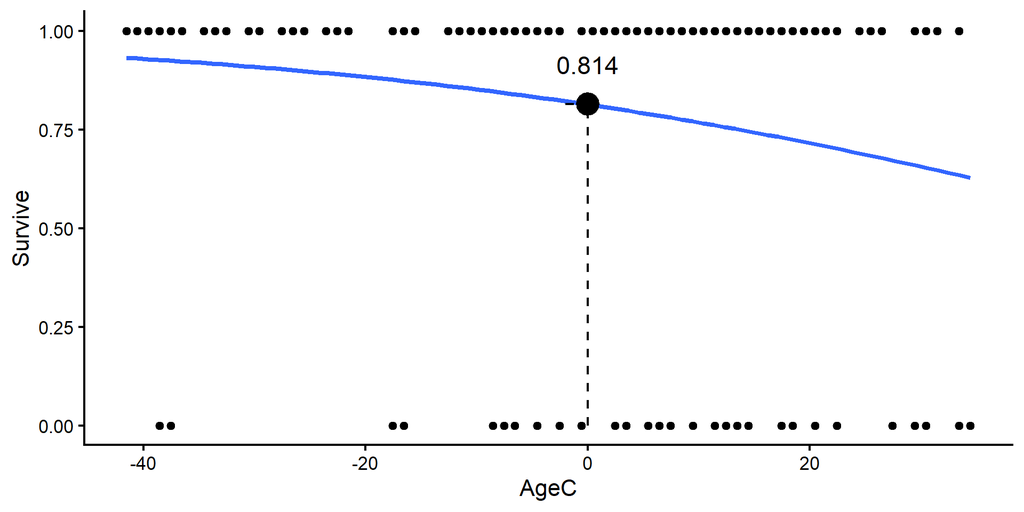

```r
int_eval <- round(eval(exp(m1_b0)) / (1 + exp(m1_b0)), 3)

ggplot(ICU,
       aes(x=AgeC,
           y=Survive)) +
  geom_point() +
  stat_smooth(method="glm",
              method.args=list(family="binomial"),
              se=FALSE) +
  annotate("segment",
           x = -2, xend = 0,
           y = int_eval, yend = int_eval,
           colour = "black", linetype = "dashed") +
  annotate("segment",
           x = 0, xend = 0,
           y = 0, yend = int_eval,
           colour = "black", linetype = "dashed") +
  annotate("pointrange",
           x = 0, y = int_eval,
           ymin = int_eval, ymax = int_eval,
           colour = "black", size = 1.5) +
  annotate("text",
           x = 0, y = int_eval + 0.1,
           colour = "black", label = int_eval, size = 6)
```

## 5.7 Interpreting probability: Example

$$\hat{p} = \frac{e^{1.474 + \color{OrangeRed}{-0.028} X}}{1 + e^{1.474 + \color{OrangeRed}{-0.028} X}}$$

- Interpretation of example **slope**
  - $b_1$ < 0: **Probability of a success decreases as X increases**
  - Probability of survival decreases as age increases
    - **But** it’s non-linear

## 5.8 Probability metric is non-linear

- Linear regression:
  - **Constant**, linear slope
  - Slope depends on the **slope only**
- Logistic regression (probability):
  - **Non-linear** slope
  - No interaction but **conditional effect**

## 5.9 Probability metric is non-linear

| AgeC | Predicted probability |
| --- | --- |
| -30 | 0.9100 |
| -20 | 0.8843 |
| -10 | 0.8525 |
| 0 | 0.8137 |
| 10 | 0.7675 |
| 20 | 0.7138 |
| 30 | 0.6534 |

## 5.10 Probability metric is non-linear

```r
ggplot(data = ICU,
       aes(x=AgeC,
           y=Survive)) +
  geom_point() +
  stat_smooth(method="glm",
              method.args=list(family="binomial"),
              se=FALSE)
```

[output not shown]

## 5.11 Probability metric is non-linear

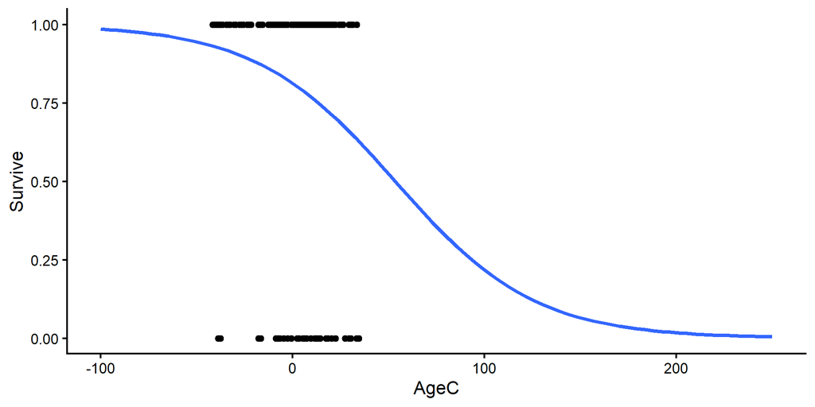

```r
ggplot(data = ICU,
       aes(x=AgeC,
           y=Survive)) +
  geom_point() +
  stat_smooth(method="glm",
              method.args=list(family="binomial"),
              se=FALSE,
              fullrange = T) +
  xlim(-100, 250)
```

## 5.12 A caution about probability equation

**Warning**

You might also see the probability defined as $\hat{p} = \frac{1}{1 + e^{-({b_{0} + b_{1} X})}}$

Or more generally, $\hat{p} = \frac{1}{1 + e^{-(Xb)}}$

- These are **numerically equivalent** to what we’ve talked about
  - But did you notice the negative sign?
  - No? You didn’t expect it and missed it in the complicated equation?
  - Yeah, that’s why we don’t use this version

# 6 Odds metric

## 6.1 What are odds?

- *Odds* is the **ratio** of **two probabilities**

$$odds = \frac{\hat{p}}{(1 - \hat{p})}$$

- Odds is the ratio of probability of a “success” ($\hat{p}$) to the probability of “not a success” $(1 − \hat{p})$

## 6.2 How do odds work?

- Probability ranges from 0 to 1, switches at 0.5
  - **Success more likely** than failure when $p > 0.5$
  - **Success less likely** than failure when $p < 0.5$
- Odds range from $0$ to $+\infty$, switches at 1
  - **Success more likely** than failure when $odds > 1$
  - **Success less likely** than failure when $odds < 1$

## 6.3 $\hat{odds} = \frac{\hat{p}}{(1 - \hat{p})} = e^{1.474 + -0.028 X}$

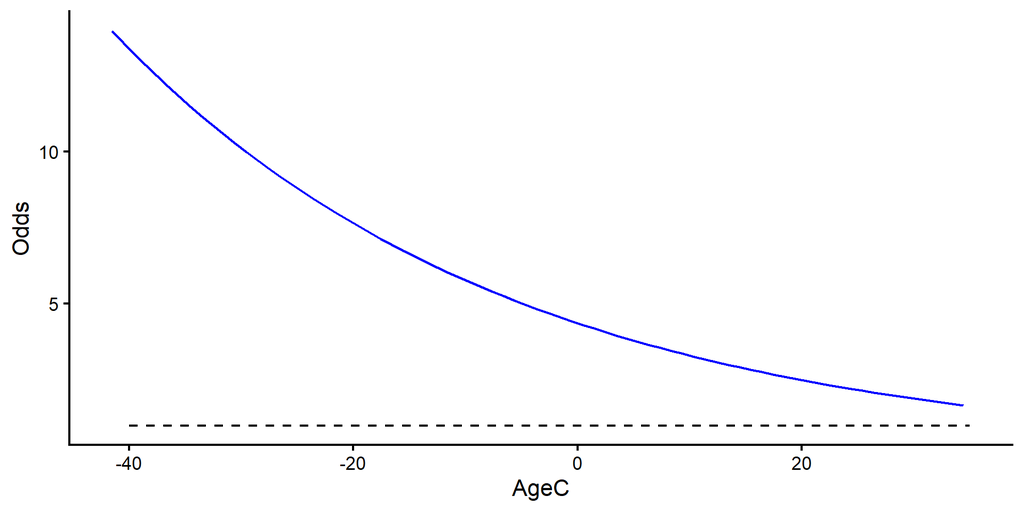

```r
ICU <- ICU %>% mutate(pred_odds = exp(m1_b0 + m1_b1 * AgeC),
                      pred_p = exp(m1_b0 + m1_b1 * AgeC) / (1 + exp(m1_b0 + m1_b1 * AgeC)),
                      obs_odds = pred_p / (1 - pred_p))

ggplot(data = ICU,
       aes(x = AgeC,
           y = obs_odds)) +
  geom_line(color="blue",
            aes(x = AgeC,
                y = pred_odds)) +
  labs (y = "Odds") +
  annotate("segment",
           x = -40, xend = 35,
           y = 1, yend = 1,
           colour = "black", linetype = "dashed")
```

## 6.4 Interpreting odds

- **Intercept**: $b_0$ is related to the **odds of success when $X$ = 0**
  - Odds of success **when X = 0**: $e^{b_0}$
  - $b_0$ > 0: Odds of success > 1 when $X$ = 0
  - $b_0$ < 0: Odds of success < 1 when $X$ = 0
- **Slope**: $b_1$ tells you how predictor X relates to **odds of success**
  - $b_1$ > 0: Odds of success **increases** as $X$ **increases**
  - $b_1$ < 0: Odds of a success **decreases** as $X$ **increases**

## 6.5 Interpreting odds: Example

$$\hat{odds} = \frac{\hat{p}}{(1 - \hat{p})} = e^{\color{OrangeRed}{1.474} + -0.028 X}$$

- Interpretation of example **intercept**
  - $b_0 > 0$ so odds of success > 1 when $X$ = 0
  - Success (1) more likely than failure (0) when $X$ = 0
  - Odds of success when $X$ = 0: $e^{\color{OrangeRed}{b_0}} = e^{\color{OrangeRed}{1.474}} = 4.37$
    - A “success” is about 4.37 times as likely as a “failure”
    - Compare to 0.814 **probability** of success: 0.814 / 0.186 = 4.38

## 6.6 Interpreting odds: Example

$$\hat{odds} = \frac{\hat{p}}{(1 - \hat{p})} = e^{1.474 + \color{OrangeRed}{-0.028} X}$$

- Interpretation of example **slope**
  - $b_1$ < 0: Odds of a success **decreases** as $X$ **increases**
  - **Odds** of survival decreases as age increases
    - But it’s non-linear

## 6.7 Odds metric is nonlinear

- This non-linear change is presented in terms of **odds ratio**
  - Constant, **multiplicative** change in predicted odds
  - For a 1-unit difference in $X$, the **predicted odds** of success is **multiplied by** the **odds ratio**
- *Example*: odds ratio $= e^{b_1}= e^{-0.028} = 0.972$
  - For a 1-unit difference in $X$, the **predicted odds** of success is **multiplied by** $0.972$
  - Each 1-unit increase in $X$ **reduces** the odds of a success

## 6.8 Odds ratio = 0.972)

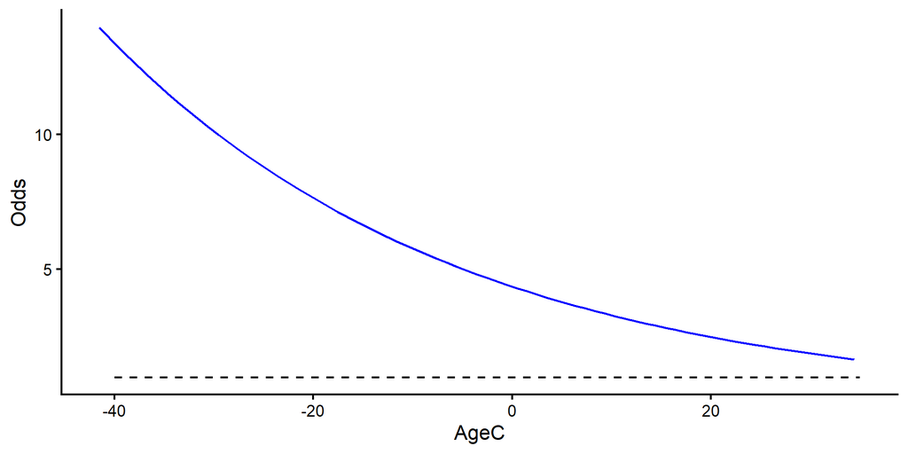

```r
ggplot(data = ICU,
       aes(x = AgeC,
           y = obs_odds)) +
  geom_line(color="blue",
            aes(x = AgeC,
                y = pred_odds)) +
  labs (y = "Odds") +
  annotate("segment",
           x = -40, xend = 35,
           y = 1, yend = 1,
           colour = "black", linetype = "dashed")
```

## 6.9 Odds metric is nonlinear

| AgeC | Predicted probability | Predicted odds |
| --- | --- | --- |
| -30 | 0.9100 | 10.1148 |
| -20 | 0.8843 | 7.6446 |
| -10 | 0.8525 | 5.7777 |
| 0 | 0.8137 | 4.3667 |
| 10 | 0.7675 | 3.3003 |
| 20 | 0.7138 | 2.4943 |
| 30 | 0.6534 | 1.8851 |

## 6.10 A caution about odds

**Warning**

- **Odds ratios** are very popular in medicine and epidemiology
- They can be **extremely** misleading
- The **same odds ratio** corresponds to many **different** probability values
  - Odds ratio $= \frac{odds = 3}{odds = 1} = 3$
    - Corresponds to probability of 0.75 vs 0.5
  - Odds ratio $= \frac{odds = 9}{odds = 3} = 3$
    - Corresponds to probability of 0.90 vs 0.75

# 7 Logit or log-odds metric

## 7.1 What is the logit?

- **Logit** or **log-odds** is the natural log ($ln$) of the odds
  - As **probability** of “success” increases (nonlinearly, S-shaped curve)
  - The *odds* of “success” increases (also nonlinearly, exponentially)
  - The **logit** of “success” increases **linearly**

## 7.2 How does the logit work?

- Probability ranges from 0 to 1, **switches at 0.5**
- Odds range from 0 to $+\infty$ , **switches at 1**
- Logit ranges from $-\infty$ to $+\infty$, **switches at 0**
  - Success more likely than failure when logit > 0
  - Success less likely than failure when logit < 0

## 7.3 $ln\left(\frac{\hat{p}}{(1 - \hat{p})}\right) = 1.474 + -0.028 X$

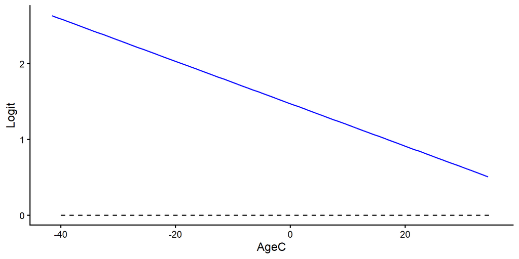

```r
ggplot(ICU, aes(x=AgeC, y=obs_odds)) +
  geom_line(color="blue", aes(x = AgeC, y = log(pred_odds))) +
  labs (y = "Logit") +
  annotate("segment", x = -40, xend = 35, y = 0, yend = 0, colour = "black", linetype = "dashed")
```

## 7.4 Interpreting logit

- **Intercept**: $b_0$ is related to the **logit of success** when **X = 0**
  - Logit of success when X = 0: $b_0$
    - $b_0$ > 0: Logit > 0 when X = 0
    - $b_0$ < 0: Logit < 0 when X = 0
- **Slope** : $b_1$ is the relationship between **predictor X** and **logit of success**
  - $b_1$ > 0: Logit of a success **increases** as X **increases**
  - $b_1$ < 0: Logit of a success **decreases** as X **increases**

## 7.5 Interpreting logit: Example

$$\hat{logit} = ln\left(\frac{\hat{p}}{(1 - \hat{p})}\right) = \color{OrangeRed}{1.474} + -0.028 X$$

- Interpretation of example **intercept**
  - $b_0$ > 0: Logit > 0 when X = 0
  - Logit of success when X = 0: $\color{OrangeRed}{b_0} = \color{OrangeRed}{1.474}$
  - Success more likely than failure when X = 0

## 7.6 Interpreting logit: Example

$$\hat{logit} = ln\left(\frac{\hat{p}}{(1 - \hat{p})}\right) = 1.474 + \color{OrangeRed}{-0.028} X$$

- Interpretation of example **slope**
  - $b_1$ < 0: Logit of a success **decreases** by $\color{OrangeRed}{-0.028}$ units when X increases by 1 unit

# 8 Miscellaneous

## 8.1 So which metric should I use?

- They are **equivalent** and give you the same information
  - Just packaged differently
- Use the metric that
  - Makes the most *sense* to you
  - You can *explain* fully
  - Is most commonly used in your *field*

## 8.2 Metrics: Some things to keep in mind

- Odds ratios tell you about **change**, but not **where you start**
  - If you report odds ratios, *also report some measure of probability* e.g., probability of success at the mean of X
  - 10x change is $5%$ to $50%$ or $0.05%$ to $0.5%$?
- Logit is nice because it’s **linear**, but it’s not very **interpretable**
  - What is a “logit”? It’s just a *mathematical* concept that makes a straight line – not actually **meaningful**
  - *But many measures don’t have meaningful metrics…*

## 8.3 Why a $z$-statistic?

- Maximum likelihood estimation
  - Estimates are assumed to be normally distributed
- Known variance
  - Binomial distribution: mean = $np$, variance = $np(1-p)$
  - Use $t$ distribution when you need to **estimate** variance
    - Use $z$ distribution when you don’t

## 8.4 Predictors in logistic regression

- Similar to linear regression
  - Continuous: Center for interpretability
  - Categorical: Code appropriately
  - Coefficients are **partial** coefficients
- Tests are $z$-tests, not $t$-tests

## 8.5 Models in logistic regression

- Add predictors in sets
  - Likelihood ratio tests to compare models
- Coefficients are in **logit metric**
  - So are the **confidence intervals**
  - Confidenct intervals in other metrics
- $R^2_{multiple}$ analogue
- Packages to make some of these things easier

## 8.6 Interactions in logistic regression

# 9 Summary

## 9.1 Summary

- Use logistic regression when your outcome is binary
  - **Don’t use linear regression**
- Be careful with interpretation no matter what
  - **Probability**: Probability *makes sense*, but it’s *nonlinear*
  - **Odds**: Odds ratio *seems to make sense* but it can be *misleading*
  - **Logit**: *Linear* but what even is a *logit*?
- But many basic concepts parallel linear regression
  - Intercept, slope(s), adding predictors, $R^2_{multiple}$

## 9.2 In class

- Run some logistic regression models
- Interpret the results
- Examples of the things we didn’t get to
  - $R^2_{multiple}$, compare models, report full results

## 9.3 Next time

- Logistic regression for **binary** outcomes
- Poisson regression for **count** outcomes
- Survival analysis for **survival** outcomes